# Lab6

Zeyuan Fang

9/15/2021

## Data Description

This data set consists of three types of entities: (a) the specification of an auto in terms of various characteristics, (b) its assigned insurance risk rating, (c) its normalized losses in use as compared to other cars. The second rating corresponds to the degree to which the auto is more risky than its price indicates. Cars are initially assigned a risk factor symbol associated with its price. Then, if it is more risky (or less), this symbol is adjusted by moving it up (or down) the scale. Actuarians call this process “symboling”. A value of +3 indicates that the auto is risky, -3 that it is probably pretty safe.

The third factor is the relative average loss payment per insured vehicle year. This value is normalized for all autos within a particular size classification (two-door small, station wagons, sports/speciality, etc…), and represents the average loss per car per year.

## Import

na.string=‘?’ will substitue question mark to NA.

```r
am.original <- read.csv('automobile-original.csv',na.string='?')
am.subset <- read.csv('automobile-subset.csv')
```

Remove NA and subsetting.

```r
am.original <- am.original[complete.cases(am.original),]
am.original <- subset(am.original,select=-engine.location)
```

Save and re-read.

```r
write.csv(am.original,"automobile.csv",row.names = F)
am.original <- read.csv("automobile.csv")
```

check whether the two are the same.

```r
all(am.original==am.subset)
```

```
## [1] TRUE
```

## Explore

#### Q1 Produce a tidier file automobile.csv.

We will use automobile.csv, so let us remove the object created by another identical file.

```r
rm(am.subset)
ls()
```

```
## [1] "am.original"
```

Check the dimension of the dataframe.

```r
dim(am.original)
```

```
## [1] 159  25
```

#### Q2 Write R code to answer the following questions:

##### What is the mean price (price) of all vehicles ?

```r
with(am.original,mean(price))
```

```
## [1] 11445.73
```

##### How many vehicles have 4 doors (num.of.doors)?

```r
with(am.original,sum(num.of.doors=='four'))
```

```
## [1] 95
```

##### What are the different engine types (engine.type) among the observations?

```r
with(am.original,unique(engine.type))
```

```
## [1] ohc  l    dohc ohcv ohcf
## Levels: dohc l ohc ohcf ohcv
```

##### How many vehicles have a price (price) higher than $20000?

```r
with(am.original,sum(price>20000))
```

```
## [1] 13
```

##### What is the mean price (price) for “4wd” (drive.wheels)?

```r
with(am.original,mean(price[drive.wheels=='4wd']))
```

```
## [1] 10241
```

#### Q3 Produce pairwise scatterplots between variables normalized.losses, wheel.base, peak.rpm and price.

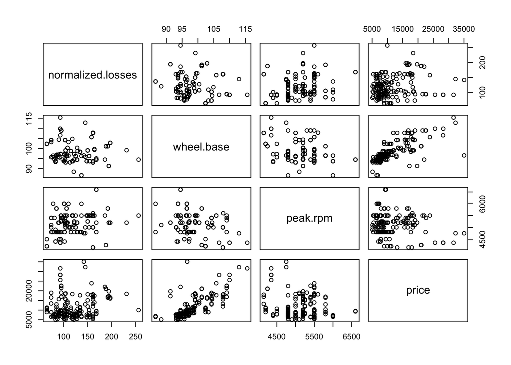

```r
pairs(am.original[,c("normalized.losses","wheel.base","peak.rpm","price")])
```

## Linear regression

#### Q4 Produce the full linear regression model with all variables included. Comment on the outcome.

```r
am.fit <- lm(price~.,data=am.original)
summary(am.fit)
```

```
##
## Call:
## lm(formula = price ~ ., data = am.original)
##
## Residuals:
##     Min      1Q  Median      3Q     Max
## -2949.8  -587.9     0.0   650.3  2259.2
##
## Coefficients: (3 not defined because of singularities)
##                         Estimate Std. Error t value Pr(>|t|)
## (Intercept)            2.309e+04  1.560e+04   1.480 0.141731
## symboling             -5.068e+00  2.163e+02  -0.023 0.981351
## normalized.losses      5.577e+00  6.252e+00   0.892 0.374295
## makebmw                3.596e+02  1.791e+03   0.201 0.841251
## makechevrolet         -4.745e+03  1.856e+03  -2.556 0.011985 *
## makedodge             -6.209e+03  1.613e+03  -3.851 0.000201 ***
## makehonda             -1.583e+03  1.739e+03  -0.910 0.364854
## makejaguar             2.431e+03  2.918e+03   0.833 0.406615
## makemazda             -4.063e+03  1.568e+03  -2.591 0.010906 *
## makemercedes-benz      2.548e+03  1.608e+03   1.584 0.116050
## makemitsubishi        -6.328e+03  1.578e+03  -4.010 0.000113 ***
## makenissan            -3.690e+03  1.470e+03  -2.510 0.013557 *
## makepeugot            -5.143e+03  4.732e+03  -1.087 0.279561
## makeplymouth          -6.025e+03  1.618e+03  -3.723 0.000316 ***
## makeporsche            4.830e+03  2.091e+03   2.310 0.022810 *
## makesaab              -4.040e+02  1.552e+03  -0.260 0.795107
## makesubaru            -7.317e+03  2.301e+03  -3.180 0.001927 **
## maketoyota            -5.869e+03  1.594e+03  -3.682 0.000364 ***
## makevolkswagen        -4.297e+03  1.355e+03  -3.170 0.001986 **
## makevolvo             -2.871e+03  1.838e+03  -1.563 0.121105
## fuel.typegas          -1.065e+04  5.139e+03  -2.072 0.040708 *
## aspirationturbo        2.171e+03  5.956e+02   3.646 0.000413 ***
## num.of.doorstwo       -8.381e+02  3.795e+02  -2.208 0.029366 *
## body.stylehardtop     -5.627e+03  1.375e+03  -4.091 8.33e-05 ***
## body.stylehatchback   -5.736e+03  1.343e+03  -4.271 4.23e-05 ***
## body.stylesedan       -5.702e+03  1.398e+03  -4.080 8.71e-05 ***
## body.stylewagon       -5.647e+03  1.414e+03  -3.995 0.000119 ***
## drive.wheelsfwd       -2.936e+01  6.501e+02  -0.045 0.964064
## drive.wheelsrwd        1.977e+03  9.553e+02   2.070 0.040895 *
## wheel.base             3.184e+02  8.310e+01   3.832 0.000215 ***
```

[output cut: 16 more lines]

```
## fuel.systemmpfi        2.602e+03  1.081e+03   2.407 0.017808 *
## fuel.systemspdi        1.081e+03  1.292e+03   0.837 0.404621
## bore                  -8.817e+02  1.427e+03  -0.618 0.538041
## stroke                -5.677e+02  9.524e+02  -0.596 0.552409
## compression.ratio     -7.000e+02  3.844e+02  -1.821 0.071380 .
## horsepower            -2.019e+01  1.911e+01  -1.057 0.292973
## peak.rpm              -5.377e-01  5.658e-01  -0.950 0.344070
## city.mpg              -1.564e+02  1.030e+02  -1.518 0.131872
## highway.mpg            1.284e+02  8.912e+01   1.441 0.152517
## ---
## Signif. codes:  0 '***' 0.001 '**' 0.01 '*' 0.05 '.' 0.1 ' ' 1
##
## Residual standard error: 1165 on 107 degrees of freedom
## Multiple R-squared:  0.9734, Adjusted R-squared:  0.9607
## F-statistic: 76.78 on 51 and 107 DF,  p-value: < 2.2e-16
```

The model is saturated, with many variables not statisticaly significant or NA parameters. We need remove some variables according to occam’s razor.

#### Q5 Remove any variable(s) that seem to cause the linear regression to fail, i.e., some coefficients may become NA. Repeat this until you can produce a meaningful “full” linear regression model (it is okay if you remove slightly more variables than necessary).

```r
am.fit2 <- lm(price~.-engine.type-num.of.cylinders-fuel.system-drive.wheels-num.of.doors-engine.size-bore-stroke-compression.ratio-horsepower-peak.rpm-city.mpg-highway.mpg-symboling-width,data=am.original)
summary(am.fit2)
```

```
##
## Call:
## lm(formula = price ~ . - engine.type - num.of.cylinders - fuel.system -
##     drive.wheels - num.of.doors - engine.size - bore - stroke -
##     compression.ratio - horsepower - peak.rpm - city.mpg - highway.mpg -
##     symboling - width, data = am.original)
##
## Residuals:
##     Min      1Q  Median      3Q     Max
## -3067.5  -723.0    53.1   735.9  3131.7
##
## Coefficients:
##                       Estimate Std. Error t value Pr(>|t|)
## (Intercept)          8137.9333  6411.9567   1.269 0.206644
## normalized.losses      10.6357     5.0549   2.104 0.037302 *
## makebmw              1652.7753   916.7682   1.803 0.073732 .
## makechevrolet       -4347.4862  1154.6139  -3.765 0.000251 ***
## makedodge           -6432.8568   928.4444  -6.929 1.77e-10 ***
## makehonda           -4103.4576   891.5774  -4.602 9.80e-06 ***
## makejaguar           2335.6263  1621.9573   1.440 0.152270
## makemazda           -3433.7906   819.0601  -4.192 5.07e-05 ***
## makemercedes-benz    4029.0799  1092.5427   3.688 0.000331 ***
## makemitsubishi      -7184.1638   877.0853  -8.191 2.11e-13 ***
## makenissan          -3796.1155   778.7509  -4.875 3.12e-06 ***
## makepeugot          -6162.7766   865.0394  -7.124 6.42e-11 ***
## makeplymouth        -6385.8343   939.9760  -6.794 3.54e-10 ***
## makeporsche          3655.2312  1500.0630   2.437 0.016175 *
## makesaab             -406.5706   929.3765  -0.437 0.662499
## makesubaru          -5284.2174   886.1475  -5.963 2.19e-08 ***
## maketoyota          -4930.6008   785.4934  -6.277 4.76e-09 ***
## makevolkswagen      -3999.5380   839.2342  -4.766 4.96e-06 ***
## makevolvo           -1957.5772   818.5441  -2.392 0.018210 *
## fuel.typegas         1168.9946   466.7873   2.504 0.013505 *
## aspirationturbo      1916.7547   353.0337   5.429 2.68e-07 ***
## body.stylehardtop   -6413.5547  1164.8260  -5.506 1.89e-07 ***
## body.stylehatchback -5643.6975  1067.9170  -5.285 5.16e-07 ***
## body.stylesedan     -4958.9468  1094.3934  -4.531 1.31e-05 ***
## body.stylewagon     -5061.3101  1149.7211  -4.402 2.21e-05 ***
## wheel.base            337.2593    67.3903   5.005 1.78e-06 ***
## length               -102.8700    34.4326  -2.988 0.003362 **
## height               -437.4721    98.9472  -4.421 2.05e-05 ***
## curb.weight             7.2664     0.6457  11.253  < 2e-16 ***
## ---
## Signif. codes:  0 '***' 0.001 '**' 0.01 '*' 0.05 '.' 0.1 ' ' 1
##
## Residual standard error: 1255 on 130 degrees of freedom
## Multiple R-squared:  0.9625, Adjusted R-squared:  0.9544
## F-statistic: 119.2 on 28 and 130 DF,  p-value: < 2.2e-16
```

```r
mean((predict(am.fit2) - am.original$price)^2)
```

```
## [1] 1286755
```

## Subset Selection

```r
library(leaps)
library(glmnet)
```

#### Q7 For the data (using your “full” set of variables), produce a subset linear regression model, using the backward selection and the AIC.

```r
am.bwd = regsubsets(price~.-engine.type-num.of.cylinders-fuel.system-drive.wheels-num.of.doors-engine.size-bore-stroke-compression.ratio-horsepower-peak.rpm-city.mpg-highway.mpg-symboling-width,am.original, nvmax=60, method="backward")
```

```r
am.s <- summary(am.bwd)
```

```r
am.bic <- am.s$bic
am.k <- rowSums(am.s$which)
n = nrow(am.original)
am.aic <- am.bic +(2- log(n))*am.k
```

#### Q8 Apply the AIC-selected model to the data and compute the resulting MSE.

```r
best<- which.min(am.aic)
beta <-coef(am.bwd,best)
am.matrix = model.matrix(price~., data=am.original)
am.matrix = am.matrix[,names(beta)]
yhat = drop(am.matrix %*% beta)
resid = am.original$price - yhat
(mse = mean(resid^2))
```

```
## [1] 1288649
```

The mse of aic-selected model is larger than that of manully selected model.

#### Q9 Create a plot that shows the predictions of your AIC-selected model against the response variable (price), using different colors for different levels of drive.wheels.

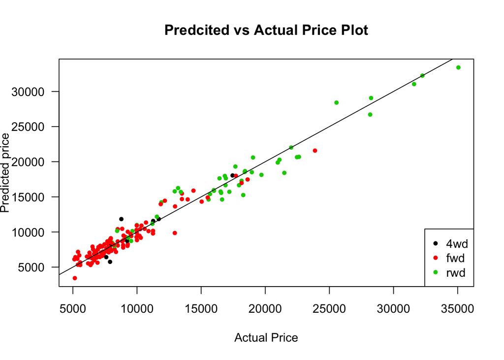

```r
plot(am.original$price,yhat,col=am.original$drive.wheels,pch=20,las =1 ,xlab= 'Actual Price', ylab= "",main = 'Predcited vs Actual Price Plot' )
title(ylab="Predicted price", line=3.3, cex.lab=1)
abline(0,1)
legend("bottomright",levels(am.original$drive.wheels),col=1:length(am.original$drive.wheels),pch=20)
```

## Lasso

#### Q10 For the data (using your “full” set of variables), compute the Lasso model.

```r
x = am.matrix[,-1]     # remove the intercept term
y = am.original$price
(am.lasso = glmnet(x, y, alpha=1))  # alpha = 0, ridge regression
```

```
##
## Call:  glmnet(x = x, y = y, alpha = 1)
##
##    Df  %Dev Lambda
## 1   0  0.00 5236.0
## 2   1 13.56 4771.0
## 3   1 24.82 4347.0
## 4   1 34.16 3961.0
## 5   1 41.92 3609.0
## 6   1 48.36 3288.0
## 7   1 53.71 2996.0
## 8   1 58.15 2730.0
## 9   1 61.83 2488.0
## 10  1 64.89 2267.0
## 11  1 67.44 2065.0
```

[output cut: 79 more lines]

```r
coef(am.lasso)
```

```
## 28 x 90 sparse Matrix of class "dgCMatrix"
```

```
##    [[ suppressing 90 column names 's0', 's1', 's2' ... ]]
```

```
##
## (Intercept)         11445.73 9062.7624987 6891.49166 4913.110545 3110.483352
## normalized.losses       .       .            .          .           .
## makebmw                 .       .            .          .           .
## makechevrolet           .       .            .          .           .
## makedodge               .       .            .          .           .
## makehonda               .       .            .          .           .
## makejaguar              .       .            .          .           .
## makemazda               .       .            .          .           .
## makemercedes-benz       .       .            .          .           .
## makemitsubishi          .       .            .          .           .
## makenissan              .       .            .          .           .
## makepeugot              .       .            .          .           .
## makeplymouth            .       .            .          .           .
## makeporsche             .       .            .          .           .
## makesubaru              .       .            .          .           .
## maketoyota              .       .            .          .           .
## makevolkswagen          .       .            .          .           .
## makevolvo               .       .            .          .           .
## fuel.typegas            .       .            .          .           .
## aspirationturbo         .       .            .          .           .
## body.stylehardtop       .       .            .          .           .
## body.stylehatchback     .       .            .          .           .
## body.stylesedan         .       .            .          .           .
## body.stylewagon         .       .            .          .           .
## wheel.base              .       .            .          .           .
## length                  .       .            .          .           .
## height                  .       .            .          .           .
## curb.weight             .       0.9682377    1.85046    2.654308    3.386744
##
## (Intercept)         1467.996590 -28.576174 -1392.197539 -2634.678541
## normalized.losses      .          .            .            .
## makebmw                .          .            .            .
## makechevrolet          .          .            .            .
## makedodge              .          .            .            .
## makehonda              .          .            .            .
## makejaguar             .          .            .            .
## makemazda              .          .            .            .
## makemercedes-benz      .          .            .            .
## makemitsubishi         .          .            .            .
```

[output cut: 612 more lines]

```
## makeporsche          3977.110484
## makesubaru          -4890.245226
## maketoyota          -4541.435881
## makevolkswagen      -3642.066668
## makevolvo           -1593.490149
## fuel.typegas         1180.684922
## aspirationturbo      1902.184723
## body.stylehardtop   -6138.562288
## body.stylehatchback -5359.519872
## body.stylesedan     -4651.015075
## body.stylewagon     -4776.996093
## wheel.base            334.736543
## length               -101.179141
## height               -431.664886
## curb.weight             7.274701
```

#### Q11 Create a coefficient profile plot of the coefficient paths that varies with the value of $\lambda$ (or log($\lambda$)).

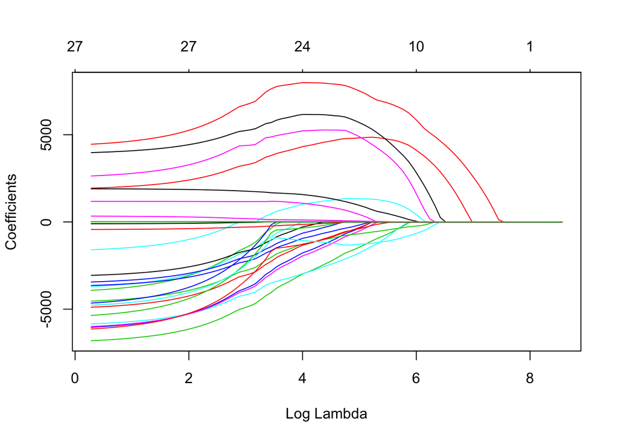

```r
plot(am.lasso,xvar="lambda")
```

#### Q12 Choose 5 different $\lambda$-values within a seemingly reasonable range (with roughly 5 to 30 variables included) and compute the MSEs of the corresponding 5 Lasso subset models. Write R code to find out how many variables (excluding the intercept) are included in each Lasso subset model.

```r
mse_v = c(NULL)
ind  = c(29,36,41,47,89)
for (i in c(1:5)){
  yhat = drop(predict(am.lasso, s=am.lasso$lambda[ind[i]], alpha=1, newx=x)) # extract coefficients
  resid = am.original$price - yhat
  mse = mean(resid^2)
  mse_v[i] =mse
}
mse_v
```

```
## [1] 4150241 2988516 2445870 2064967 1290918
```

For the Lasso subset models, the number of variablesfare:

```r
am.lasso$df[ind]
```

```
## [1] 10 15 19 24 27
```

## Summary

In this lab, we mainly focus on linear regression using automobile dataset. First we remove na value and subset useful attributes. After having tidy dataset, we explore some statistical question about the data. Then we build a linear model including all variables and manually remove some unreasonable variables which we call it “full” model. Based on the “full model”, we do subset selection according to AIC and lasso regression. From the perspective of mse, the “full model” is better than subset selection and lasso selected model.